# lab5-group13

## Data Visualization Lab -- Diamonds

[figure not shown]

### 1. Load and explore data

```python
%pylab inline
import pandas as pd
import seaborn as sns
```

```python
df = pd.read_csv('diamonds.csv')
```

#### look at the dataframe:

```python
df.head()
```

|  | ID | Carat Weight | Cut | Color | Clarity | Polish | Symmetry | Report | Price |
| --- | --- | --- | --- | --- | --- | --- | --- | --- | --- |
| 0 | 1 | 1.10 | Ideal | H | SI1 | VG | EX | GIA | 5169 |
| 1 | 2 | 0.83 | Ideal | H | VS1 | ID | ID | AGSL | 3470 |
| 2 | 3 | 0.85 | Ideal | H | SI1 | EX | EX | GIA | 3183 |
| 3 | 4 | 0.91 | Ideal | E | SI1 | VG | VG | GIA | 4370 |
| 4 | 5 | 0.83 | Ideal | G | SI1 | EX | EX | GIA | 3171 |

We find that the first column is ID, which is useless for analysis, so we delete it.

```python
df.drop('ID',axis=1,inplace=True)
```

#### check data type and missing value:

```python
df.info()
```

```
<class 'pandas.core.frame.DataFrame'>
RangeIndex: 6000 entries, 0 to 5999
Data columns (total 8 columns):
Carat Weight    6000 non-null float64
Cut             6000 non-null object
Color           6000 non-null object
Clarity         6000 non-null object
Polish          6000 non-null object
Symmetry        6000 non-null object
Report          6000 non-null object
Price           6000 non-null int64
dtypes: float64(1), int64(1), object(6)
memory usage: 375.1+ KB
```

There is no missing value in the dataset.

#### check numerical varibles' distribution:

```python
df.describe()
```

|  | Carat Weight | Price |
| --- | --- | --- |
| count | 6000.000000 | 6000.000000 |
| mean | 1.334520 | 11791.579333 |
| std | 0.475696 | 10184.350051 |
| min | 0.750000 | 2184.000000 |
| 25% | 1.000000 | 5150.500000 |
| 50% | 1.130000 | 7857.000000 |
| 75% | 1.590000 | 15036.500000 |
| max | 2.910000 | 101561.000000 |

The median of Price is less than the mean, so the price is right-skewed. We think it makes sense like other luxury items.

### 2. Explore relationship among varibles

#### Cut vs Price

Diamond Cut specifically refers to the quality of a diamond’s angles, proportions, symmetrical facets, brilliance, fire, scintillation and finishing details. These factors directly impact a diamond’s ability to sparkle, along with its overall aesthetic appeal.

The GIA grades Diamond Cut on the scale of Ideal, Excellent, Very Good, Good, Fair and Poor. The Ideal and Excellent grades, depending on Diamond Shape, signify proportions and angles cut for maximum brilliance and fire.  
Source: https://www.diamonds.pro/education/4cs-diamonds/

[figure not shown]

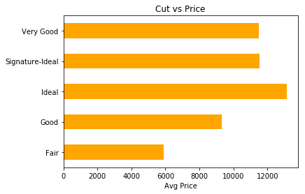

```python
df.groupby(by='Cut')['Price'].mean().plot(kind='barh',color = 'orange')
plt.title('Cut vs Price')
plt.xlabel('Avg Price')
plt.ylabel('');
```

#### Color vs Price

Diamond Color is graded in terms of how white or colorless a diamond is. The GIA grades diamonds from D to Z, with D being the most colorless, and Z containing noticeable brown or yellow tint.

Color scale:

[figure not shown]

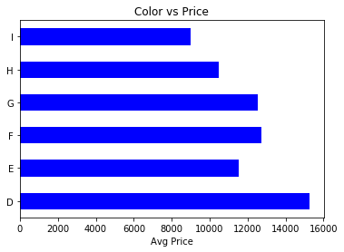

```python
df.groupby(by='Color')['Price'].mean().plot(kind='barh',color = 'blue')
plt.title('Color vs Price')
plt.ylabel('')
plt.xlabel('Avg Price');
```

#### Clarity vs Price

A Diamond’s Clarity grade evaluates how clean a diamond is from both inclusions and blemishes. Clarity is graded by the GIA on the following scale:

FL (Flawless)  
IF (Internally Flawless)  
VVS1 (Very, Very Slightly Included 1)  
VVS2 (Very, Very Slightly Included 2)  
VS1 (Very Slightly Included 1)  
VS2 (Very Slightly Included 2)  
SI1 (Slightly Included 1)  
SI2 (Slightly Included 2)  
I1 (Inclusions 1)  
I2 (Inclusions 2)

[figure not shown]

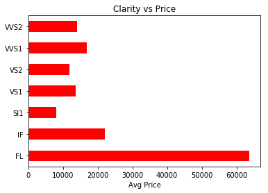

```python
df.groupby(by='Clarity')['Price'].mean().plot(kind='barh',color = 'red')
plt.title('Clarity vs Price')
plt.ylabel('')
plt.xlabel('Avg Price');
```

#### Polish vs Price

Polish refers to the degree of smoothness of each facet of a diamond as measured by a gemologist.

EX: Excellent. No polish defects visible at 10x magnification.  
VG: Very Good. Any defects are extremely difficult to see at 10x magnification.  
G: Good. Any defects are difficult to see at 10x magnification.

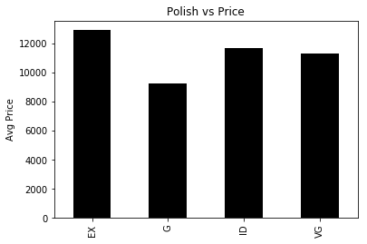

```python
df.groupby(by='Polish')['Price'].mean().plot(kind='bar',color = 'black')
plt.title('Polish vs Price')
plt.xlabel('')
plt.ylabel('Avg Price');
```

#### Symmetry vs Price

As the name implies, diamond symmetry simply refers to how symmetrical a diamond’s facets and angles are. For diamonds with a symmetry grade of Excellent to Good, symmetry should not be used as a primary factor in choosing a diamond, since each of these grades is possible in diamonds of exceptional appearance.

For diamonds with a symmetry grade of Excellent to Good, symmetry should not be used as a primary factor in choosing a diamond, since each of these grades is possible in diamonds of exceptional appearance.  
Source: https://blog.brilliance.com/diamonds/what-is-the-symmetry-of-a-diamond

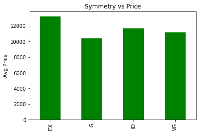

```python
df.groupby(by='Symmetry')['Price'].mean().plot(kind='bar',color = 'green')
plt.title('Symmetry vs Price')
plt.xlabel('')
plt.ylabel('Avg Price');
```

We find that Polish and Symmetry are very similar in impacting mean price, because they are parts of Cut. Also, they do not have very significant differences among different grades, so we will focus on other variables to tell story.

#### Report vs Price

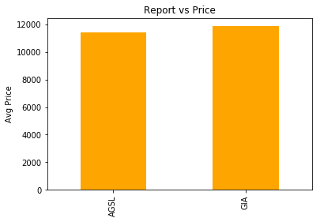

```python
df.groupby(by='Report')['Price'].mean().plot(kind='bar',color = 'orange')
plt.title('Report vs Price')
plt.xlabel('')
plt.ylabel('Avg Price');
```

As we can see, the mean prices from GIA and AGSL are not very different. Plus, we are not sure about the "AGSL", so we think this variable is not significant for impacting price.

#### Carat Weight vs Price:

One carat equals 200 milligrams or 1/5 of a gram in weight. For diamonds under one carat, each carat is divided into 100 points — similar to pennies in a dollar. 0.75 ct. = 75 points, 1/2 ct. = 50 points.  
Source: https://ncjewelryappraiser.com/jewelry-appraisal-services/key-factors-for-determining-the-value-of-a-diamond/

```python
df['Carat Weight'].corr(df['Price'])
```

```
0.8585621341250121
```

### 3. Tell story

The key to a diamond’s value is its rarity, and no two diamonds are alike. Rarity is determined by a diamond’s unique characteristics as measured by the Four Cs: Cut, Color, Clarity and Carat Weight. Thus, our story is mainly based on the relationship between the Cut, Clarity, Carat Weight and Diamonds Price.

#### Part 1: Carat Weight and Price

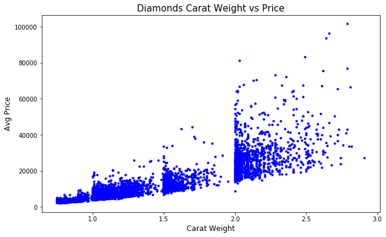

```python
plt.figure(figsize= (10,6))
plt.plot(df['Carat Weight'],df['Price'],'b.')
plt.title('Diamonds Carat Weight vs Price',fontsize=15)
plt.xlabel('Carat Weight',fontsize=12)
plt.ylabel('Avg Price',fontsize=12);
```

Analysis:

- From previous analysis, the Carat Weight has highly positive relationship with Price -- 0.86. As we can see, there is a clear bound line in the scatter plot showing the specific relationship between entire carat weight range and the correspoding minimum prices.
- Also, we find that as carat weight increases, the range of possible prices also increases. We think that this may be caused by more flexibility and modification of diamond making process. For example, a heavier diamond means a bigger volumn. This is convenient for improving beauty, quality and clarity of the diamonds, like by precisely cutting and modifying, compared to the smaller ones.

#### Part 2: Cut, Clarity and Price

```python
cross = pd.crosstab(index=df.Cut,columns= df.Clarity,values=df.Price,aggfunc="mean",).loc[['Fair','Good','Very Good','Ideal','Signature-Ideal']]
cross = cross[['FL', 'IF','VVS1','VVS2','VS1','VS2','SI1']]
cross
```

| Clarity Cut | FL | IF | VVS1 | VVS2 | VS1 | VS2 | SI1 |
| --- | --- | --- | --- | --- | --- | --- | --- |
| Fair | NaN | 11618.000000 | 4115.000000 | 8204.750000 | 5035.941176 | 7520.093750 | 4928.608696 |
| Good | NaN | 17822.000000 | 15697.666667 | 9544.105263 | 11505.266055 | 10523.310526 | 7430.792507 |
| Very Good | NaN | 22431.000000 | 16241.715686 | 14137.244444 | 13472.571744 | 11567.024133 | 8059.656951 |
| Ideal | 65180.5 | 22052.911765 | 17813.064935 | 14761.413408 | 14872.637708 | 12823.264063 | 8644.516788 |
| Signature-Ideal | 62371.5 | 30733.428571 | 13460.947368 | 14186.756757 | 11590.638889 | 9667.220000 | 7296.575758 |

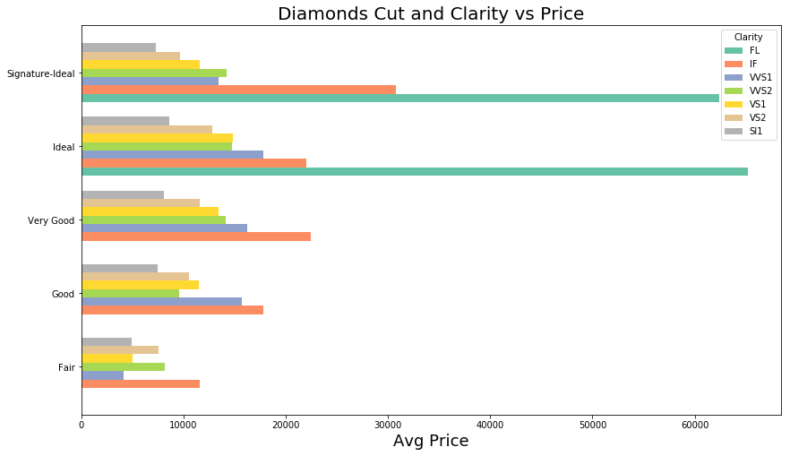

```python
cross.plot(kind='barh',figsize=(14,8), fontsize=10,width=0.8,colormap='Set2',title='Avg Price by Cut and Clarity')
plt.title('Diamonds Cut and Clarity vs Price',fontsize=20)
plt.xlabel("Avg Price",fontsize=18)
plt.ylabel("");
```

Analysis:

In general, for each Cut grade, the higher the Clarity grade is, the higher the average price will be. For each Clarity grade, the higher the Cut grade is, the higher the average price will be. However, there are some exceptions:

- FL(Flawless) only exists in Ideal and Signature-Ideal, which means the higher Cut quality is, the higher Clarity grade and the higher prices of diamonds will be.
- For Signature-Ideal grade of Cut, we find that VVS1 has lower average prices than VVS2, which is strange. We think the factor can be Symmetry, because Symmetry is more important in diamonds of VVS2 Clarity and higher.
- For Fair grade of Cut, there are no clear price rules to follow.